# Risk Factor Analysis

## Outcome Variable

**Outcome Variable:** ever_stunted

## Predictor Variables

**Intervention Variable:** mbmi

**Adjustment Set:**

- arm
- W_mage
- meducyrs
- feducyrs
- W_nchldlt5
- brthmon
- W_parity
- delta_W_mage
- delta_meducyrs
- delta_feducyrs
- delta_W_nchldlt5
- delta_brthmon
- delta_W_parity

## Stratifying Variables

The analysis was stratified on these variable(s):

- agecat
- studyid
- country

## Data Summary

| agecat | studyid | country | mbmi | ever_stunted | n_cell | n |
| --- | --- | --- | --- | --- | --- | --- |
| 0-24 months | iLiNS-Zinc | BURKINA FASO | Normal weight | 0 | 1803 | 3216 |
| 0-24 months | iLiNS-Zinc | BURKINA FASO | Normal weight | 1 | 959 | 3216 |
| 0-24 months | iLiNS-Zinc | BURKINA FASO | Underweight | 0 | 266 | 3216 |
| 0-24 months | iLiNS-Zinc | BURKINA FASO | Underweight | 1 | 188 | 3216 |
| 0-24 months | JiVitA-3 | BANGLADESH | Normal weight | 0 | 8183 | 27105 |
| 0-24 months | JiVitA-3 | BANGLADESH | Normal weight | 1 | 8539 | 27105 |
| 0-24 months | JiVitA-3 | BANGLADESH | Underweight | 0 | 5491 | 27105 |
| 0-24 months | JiVitA-3 | BANGLADESH | Underweight | 1 | 4892 | 27105 |
| 0-24 months | LCNI-5 | MALAWI | Normal weight | 0 | 259 | 837 |
| 0-24 months | LCNI-5 | MALAWI | Normal weight | 1 | 433 | 837 |
| 0-24 months | LCNI-5 | MALAWI | Underweight | 0 | 46 | 837 |
| 0-24 months | LCNI-5 | MALAWI | Underweight | 1 | 99 | 837 |
| 0-24 months | MAL-ED | BANGLADESH | Normal weight | 0 | 89 | 254 |
| 0-24 months | MAL-ED | BANGLADESH | Normal weight | 1 | 133 | 254 |
| 0-24 months | MAL-ED | BANGLADESH | Underweight | 0 | 9 | 254 |
| 0-24 months | MAL-ED | BANGLADESH | Underweight | 1 | 23 | 254 |
| 0-24 months | MAL-ED | BRAZIL | Normal weight | 0 | 158 | 221 |
| 0-24 months | MAL-ED | BRAZIL | Normal weight | 1 | 53 | 221 |
| 0-24 months | MAL-ED | BRAZIL | Underweight | 0 | 6 | 221 |
| 0-24 months | MAL-ED | BRAZIL | Underweight | 1 | 4 | 221 |
| 0-24 months | MAL-ED | INDIA | Normal weight | 0 | 74 | 242 |
| 0-24 months | MAL-ED | INDIA | Normal weight | 1 | 119 | 242 |
| 0-24 months | MAL-ED | INDIA | Underweight | 0 | 19 | 242 |
| 0-24 months | MAL-ED | INDIA | Underweight | 1 | 30 | 242 |
| 0-24 months | MAL-ED | NEPAL | Normal weight | 0 | 155 | 238 |
| 0-24 months | MAL-ED | NEPAL | Normal weight | 1 | 83 | 238 |
| 0-24 months | MAL-ED | NEPAL | Underweight | 0 | 0 | 238 |
| 0-24 months | MAL-ED | NEPAL | Underweight | 1 | 0 | 238 |
| 0-24 months | MAL-ED | PERU | Normal weight | 0 | 102 | 290 |
| 0-24 months | MAL-ED | PERU | Normal weight | 1 | 183 | 290 |

[output cut: 170 more lines]

The following strata were considered:

- agecat: 0-24 months, studyid: iLiNS-Zinc, country: BURKINA FASO
- agecat: 0-24 months, studyid: JiVitA-3, country: BANGLADESH
- agecat: 0-24 months, studyid: LCNI-5, country: MALAWI
- agecat: 0-24 months, studyid: MAL-ED, country: BANGLADESH
- agecat: 0-24 months, studyid: MAL-ED, country: BRAZIL
- agecat: 0-24 months, studyid: MAL-ED, country: INDIA
- agecat: 0-24 months, studyid: MAL-ED, country: NEPAL
- agecat: 0-24 months, studyid: MAL-ED, country: PERU
- agecat: 0-24 months, studyid: MAL-ED, country: SOUTH AFRICA
- agecat: 0-24 months, studyid: MAL-ED, country: TANZANIA, UNITED REPUBLIC OF
- agecat: 0-24 months, studyid: NIH-Birth, country: BANGLADESH
- agecat: 0-24 months, studyid: NIH-Crypto, country: BANGLADESH
- agecat: 0-24 months, studyid: PROBIT, country: BELARUS
- agecat: 0-24 months, studyid: PROVIDE, country: BANGLADESH
- agecat: 0-24 months, studyid: SAS-CompFeed, country: INDIA
- agecat: 0-24 months, studyid: TanzaniaChild2, country: TANZANIA, UNITED REPUBLIC OF
- agecat: 0-24 months, studyid: ZVITAMBO, country: ZIMBABWE
- agecat: 0-6 months, studyid: JiVitA-3, country: BANGLADESH
- agecat: 0-6 months, studyid: LCNI-5, country: MALAWI
- agecat: 0-6 months, studyid: MAL-ED, country: BANGLADESH
- agecat: 0-6 months, studyid: MAL-ED, country: BRAZIL
- agecat: 0-6 months, studyid: MAL-ED, country: INDIA
- agecat: 0-6 months, studyid: MAL-ED, country: NEPAL
- agecat: 0-6 months, studyid: MAL-ED, country: PERU
- agecat: 0-6 months, studyid: MAL-ED, country: SOUTH AFRICA
- agecat: 0-6 months, studyid: MAL-ED, country: TANZANIA, UNITED REPUBLIC OF
- agecat: 0-6 months, studyid: NIH-Birth, country: BANGLADESH
- agecat: 0-6 months, studyid: NIH-Crypto, country: BANGLADESH
- agecat: 0-6 months, studyid: PROBIT, country: BELARUS
- agecat: 0-6 months, studyid: PROVIDE, country: BANGLADESH
- agecat: 0-6 months, studyid: SAS-CompFeed, country: INDIA
- agecat: 0-6 months, studyid: TanzaniaChild2, country: TANZANIA, UNITED REPUBLIC OF
- agecat: 0-6 months, studyid: ZVITAMBO, country: ZIMBABWE
- agecat: 6-24 months, studyid: iLiNS-Zinc, country: BURKINA FASO
- agecat: 6-24 months, studyid: JiVitA-3, country: BANGLADESH
- agecat: 6-24 months, studyid: LCNI-5, country: MALAWI
- agecat: 6-24 months, studyid: MAL-ED, country: BANGLADESH
- agecat: 6-24 months, studyid: MAL-ED, country: BRAZIL
- agecat: 6-24 months, studyid: MAL-ED, country: INDIA
- agecat: 6-24 months, studyid: MAL-ED, country: NEPAL
- agecat: 6-24 months, studyid: MAL-ED, country: PERU
- agecat: 6-24 months, studyid: MAL-ED, country: SOUTH AFRICA
- agecat: 6-24 months, studyid: MAL-ED, country: TANZANIA, UNITED REPUBLIC OF
- agecat: 6-24 months, studyid: NIH-Birth, country: BANGLADESH
- agecat: 6-24 months, studyid: NIH-Crypto, country: BANGLADESH
- agecat: 6-24 months, studyid: PROBIT, country: BELARUS
- agecat: 6-24 months, studyid: PROVIDE, country: BANGLADESH
- agecat: 6-24 months, studyid: SAS-CompFeed, country: INDIA
- agecat: 6-24 months, studyid: TanzaniaChild2, country: TANZANIA, UNITED REPUBLIC OF
- agecat: 6-24 months, studyid: ZVITAMBO, country: ZIMBABWE

### Dropped Strata

Some strata were dropped due to rare outcomes:

- agecat: 0-24 months, studyid: MAL-ED, country: BRAZIL
- agecat: 0-24 months, studyid: MAL-ED, country: NEPAL
- agecat: 0-24 months, studyid: MAL-ED, country: PERU
- agecat: 0-24 months, studyid: MAL-ED, country: SOUTH AFRICA
- agecat: 0-24 months, studyid: MAL-ED, country: TANZANIA, UNITED REPUBLIC OF
- agecat: 0-6 months, studyid: MAL-ED, country: BRAZIL
- agecat: 0-6 months, studyid: MAL-ED, country: NEPAL
- agecat: 0-6 months, studyid: MAL-ED, country: PERU
- agecat: 0-6 months, studyid: MAL-ED, country: SOUTH AFRICA
- agecat: 6-24 months, studyid: MAL-ED, country: BRAZIL
- agecat: 6-24 months, studyid: MAL-ED, country: NEPAL
- agecat: 6-24 months, studyid: MAL-ED, country: PERU
- agecat: 6-24 months, studyid: MAL-ED, country: SOUTH AFRICA
- agecat: 6-24 months, studyid: MAL-ED, country: TANZANIA, UNITED REPUBLIC OF

## Methods Detail

We’re interested in the causal parameters $E[Y_a]$ for all values of $a \in \mathcal{A}$. These parameters represent the mean outcome if, possibly contrary to fact, we intervened to set all units to have $A=a$. Under the randomization and positivity assumptions, these are identified by the statistical parameters $\psi_a=E_W[E_{Y|A,W}(Y|A=a,W)]$. In addition, we’re interested in the mean of $Y$, $E[Y]$ under no intervention (the observed mean). We will estimate these parameters by using SuperLearner to fit the relevant likelihood factors – $E_{Y|A,W}(Y|A=a,W)$ and $p(A=a|W)$, and then updating our likelihood fit using a joint TMLE.

For unadjusted analyses ($W=\{\}$), initial likelihoods were estimated using Lrnr_glm to estimate the simple $E(Y|A)$ and Lrnr_mean to estimate $p(A)$. For adjusted analyses, a small library containing Lrnr_glmnet, Lrnr_xgboost, and Lrnr_mean was used.

Having estimated these parameters, we will then use the delta method to estimate relative risks and attributable risks relative to a prespecified baseline level of $A$.

# Results Detail

## Results Plots

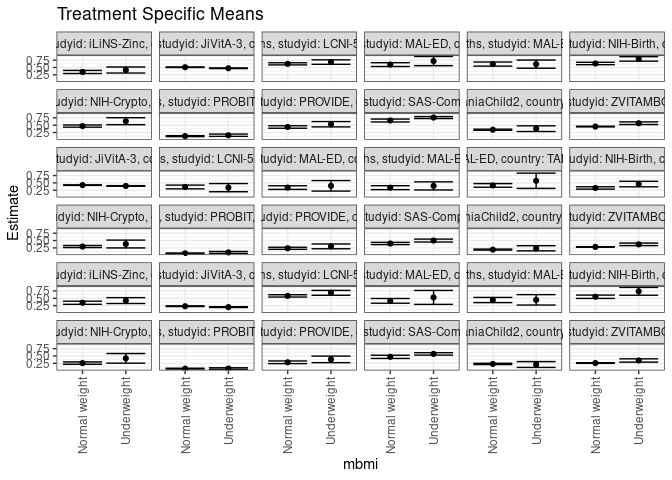

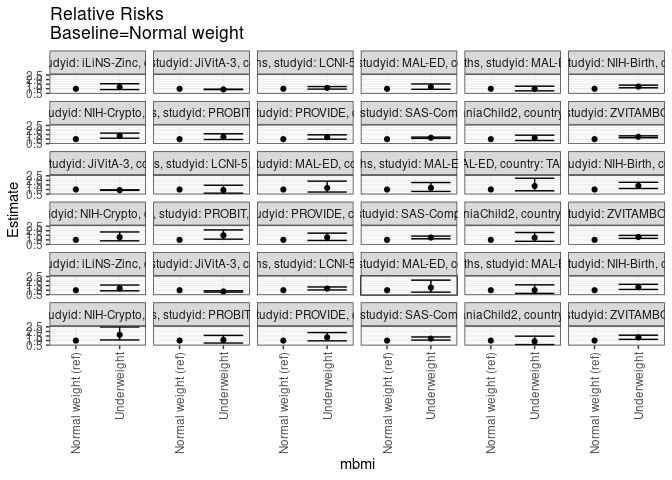

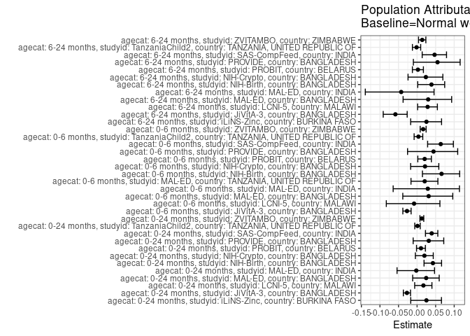

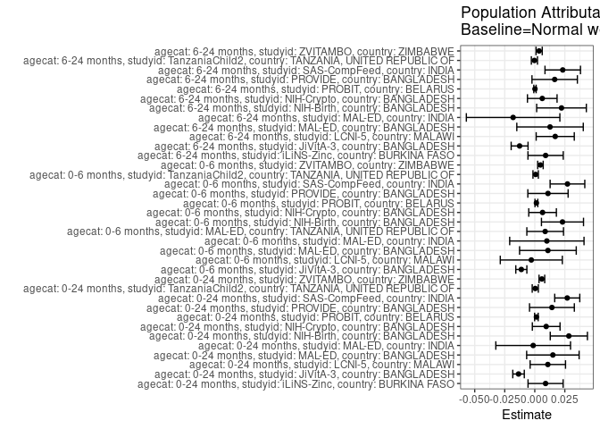

## Results Table

### Parameter: TSM

| agecat | studyid | country | intervention_level | baseline_level | estimate | ci_lower | ci_upper |
| --- | --- | --- | --- | --- | --- | --- | --- |
| 0-24 months | iLiNS-Zinc | BURKINA FASO | Normal weight | NA | 0.3476673 | 0.2948127 | 0.4005218 |
| 0-24 months | iLiNS-Zinc | BURKINA FASO | Underweight | NA | 0.4139155 | 0.3111445 | 0.5166865 |
| 0-24 months | JiVitA-3 | BANGLADESH | Normal weight | NA | 0.5090400 | 0.4996740 | 0.5184059 |
| 0-24 months | JiVitA-3 | BANGLADESH | Underweight | NA | 0.4740440 | 0.4632463 | 0.4848417 |
| 0-24 months | LCNI-5 | MALAWI | Normal weight | NA | 0.6247437 | 0.5886318 | 0.6608557 |
| 0-24 months | LCNI-5 | MALAWI | Underweight | NA | 0.6853020 | 0.6092611 | 0.7613429 |
| 0-24 months | MAL-ED | BANGLADESH | Normal weight | NA | 0.5990991 | 0.5345045 | 0.6636937 |
| 0-24 months | MAL-ED | BANGLADESH | Underweight | NA | 0.7187500 | 0.5626637 | 0.8748363 |
| 0-24 months | MAL-ED | INDIA | Normal weight | NA | 0.6170372 | 0.5481815 | 0.6858929 |
| 0-24 months | MAL-ED | INDIA | Underweight | NA | 0.6149105 | 0.4761186 | 0.7537025 |
| 0-24 months | NIH-Birth | BANGLADESH | Normal weight | NA | 0.6361926 | 0.5949220 | 0.6774631 |
| 0-24 months | NIH-Birth | BANGLADESH | Underweight | NA | 0.7919689 | 0.7156882 | 0.8682495 |
| 0-24 months | NIH-Crypto | BANGLADESH | Normal weight | NA | 0.4699711 | 0.4325253 | 0.5074170 |
| 0-24 months | NIH-Crypto | BANGLADESH | Underweight | NA | 0.6367876 | 0.5180717 | 0.7555035 |
| 0-24 months | PROBIT | BELARUS | Normal weight | NA | 0.1271435 | 0.1106336 | 0.1436533 |
| 0-24 months | PROBIT | BELARUS | Underweight | NA | 0.1569599 | 0.1180853 | 0.1958345 |
| 0-24 months | PROVIDE | BANGLADESH | Normal weight | NA | 0.4386406 | 0.3969207 | 0.4803605 |
| 0-24 months | PROVIDE | BANGLADESH | Underweight | NA | 0.5321961 | 0.4409986 | 0.6233936 |
| 0-24 months | SAS-CompFeed | INDIA | Normal weight | NA | 0.6595331 | 0.6100315 | 0.7090348 |
| 0-24 months | SAS-CompFeed | INDIA | Underweight | NA | 0.7603583 | 0.7268671 | 0.7938495 |
| 0-24 months | TanzaniaChild2 | TANZANIA, UNITED REPUBLIC OF | Normal weight | NA | 0.3450119 | 0.3254155 | 0.3646083 |
| 0-24 months | TanzaniaChild2 | TANZANIA, UNITED REPUBLIC OF | Underweight | NA | 0.3818237 | 0.2849385 | 0.4787088 |
| 0-24 months | ZVITAMBO | ZIMBABWE | Normal weight | NA | 0.4530048 | 0.4428816 | 0.4631279 |
| 0-24 months | ZVITAMBO | ZIMBABWE | Underweight | NA | 0.5671191 | 0.5227471 | 0.6114912 |
| 0-6 months | JiVitA-3 | BANGLADESH | Normal weight | NA | 0.4242356 | 0.4152417 | 0.4332294 |
| 0-6 months | JiVitA-3 | BANGLADESH | Underweight | NA | 0.3951408 | 0.3848823 | 0.4053993 |
| 0-6 months | LCNI-5 | MALAWI | Normal weight | NA | 0.3608283 | 0.2976510 | 0.4240056 |
| 0-6 months | LCNI-5 | MALAWI | Underweight | NA | 0.3372323 | 0.1975479 | 0.4769166 |
| 0-6 months | MAL-ED | BANGLADESH | Normal weight | NA | 0.3394596 | 0.2771667 | 0.4017525 |
| 0-6 months | MAL-ED | BANGLADESH | Underweight | NA | 0.3989193 | 0.2190948 | 0.5787438 |
| 0-6 months | MAL-ED | INDIA | Normal weight | NA | 0.3370586 | 0.2701751 | 0.4039422 |
| 0-6 months | MAL-ED | INDIA | Underweight | NA | 0.3976354 | 0.2589008 | 0.5363701 |
| 0-6 months | MAL-ED | TANZANIA, UNITED REPUBLIC OF | Normal weight | NA | 0.4132231 | 0.3510620 | 0.4753843 |
| 0-6 months | MAL-ED | TANZANIA, UNITED REPUBLIC OF | Underweight | NA | 0.5714286 | 0.3116959 | 0.8311612 |
| 0-6 months | NIH-Birth | BANGLADESH | Normal weight | NA | 0.3266985 | 0.2865086 | 0.3668885 |
| 0-6 months | NIH-Birth | BANGLADESH | Underweight | NA | 0.4597512 | 0.3649646 | 0.5545377 |
| 0-6 months | NIH-Crypto | BANGLADESH | Normal weight | NA | 0.2968276 | 0.2623485 | 0.3313066 |
| 0-6 months | NIH-Crypto | BANGLADESH | Underweight | NA | 0.3827382 | 0.2485924 | 0.5168841 |
| 0-6 months | PROBIT | BELARUS | Normal weight | NA | 0.0642919 | 0.0535590 | 0.0750249 |
| 0-6 months | PROBIT | BELARUS | Underweight | NA | 0.0963918 | 0.0637340 | 0.1290497 |
| 0-6 months | PROVIDE | BANGLADESH | Normal weight | NA | 0.2371412 | 0.2012668 | 0.2730155 |
| 0-6 months | PROVIDE | BANGLADESH | Underweight | NA | 0.3018432 | 0.2197680 | 0.3839184 |
| 0-6 months | SAS-CompFeed | INDIA | Normal weight | NA | 0.3994343 | 0.3612456 | 0.4376230 |
| 0-6 months | SAS-CompFeed | INDIA | Underweight | NA | 0.5008667 | 0.4505542 | 0.5511793 |
| 0-6 months | TanzaniaChild2 | TANZANIA, UNITED REPUBLIC OF | Normal weight | NA | 0.1920243 | 0.1758027 | 0.2082459 |
| 0-6 months | TanzaniaChild2 | TANZANIA, UNITED REPUBLIC OF | Underweight | NA | 0.2368421 | 0.1492053 | 0.3244789 |
| 0-6 months | ZVITAMBO | ZIMBABWE | Normal weight | NA | 0.2822016 | 0.2730437 | 0.2913596 |
| 0-6 months | ZVITAMBO | ZIMBABWE | Underweight | NA | 0.3710868 | 0.3274854 | 0.4146882 |
| 6-24 months | iLiNS-Zinc | BURKINA FASO | Normal weight | NA | 0.3476462 | 0.2947407 | 0.4005518 |
| 6-24 months | iLiNS-Zinc | BURKINA FASO | Underweight | NA | 0.4214063 | 0.3209199 | 0.5218927 |
| 6-24 months | JiVitA-3 | BANGLADESH | Normal weight | NA | 0.2289882 | 0.2166628 | 0.2413135 |
| 6-24 months | JiVitA-3 | BANGLADESH | Underweight | NA | 0.1977353 | 0.1844697 | 0.2110009 |
| 6-24 months | LCNI-5 | MALAWI | Normal weight | NA | 0.5813321 | 0.5418934 | 0.6207708 |
| 6-24 months | LCNI-5 | MALAWI | Underweight | NA | 0.6853677 | 0.6021380 | 0.7685974 |
| 6-24 months | MAL-ED | BANGLADESH | Normal weight | NA | 0.4113475 | 0.3298675 | 0.4928275 |
| 6-24 months | MAL-ED | BANGLADESH | Underweight | NA | 0.5294118 | 0.2913884 | 0.7674352 |
| 6-24 months | MAL-ED | INDIA | Normal weight | NA | 0.4401180 | 0.3522845 | 0.5279515 |
| 6-24 months | MAL-ED | INDIA | Underweight | NA | 0.4472639 | 0.2697375 | 0.6247903 |
| 6-24 months | NIH-Birth | BANGLADESH | Normal weight | NA | 0.5516648 | 0.4948709 | 0.6084586 |
| 6-24 months | NIH-Birth | BANGLADESH | Underweight | NA | 0.7370110 | 0.6036396 | 0.8703824 |
| 6-24 months | NIH-Crypto | BANGLADESH | Normal weight | NA | 0.2566204 | 0.2168007 | 0.2964401 |
| 6-24 months | NIH-Crypto | BANGLADESH | Underweight | NA | 0.4180733 | 0.2534234 | 0.5827231 |
| 6-24 months | PROBIT | BELARUS | Normal weight | NA | 0.0671642 | 0.0544711 | 0.0798573 |
| 6-24 months | PROBIT | BELARUS | Underweight | NA | 0.0717508 | 0.0463785 | 0.0971232 |
| 6-24 months | PROVIDE | BANGLADESH | Normal weight | NA | 0.2838779 | 0.2386370 | 0.3291188 |
| 6-24 months | PROVIDE | BANGLADESH | Underweight | NA | 0.3838476 | 0.2725199 | 0.4951752 |
| 6-24 months | SAS-CompFeed | INDIA | Normal weight | NA | 0.4706689 | 0.4158704 | 0.5254673 |
| 6-24 months | SAS-CompFeed | INDIA | Underweight | NA | 0.5706759 | 0.5297057 | 0.6116462 |
| 6-24 months | TanzaniaChild2 | TANZANIA, UNITED REPUBLIC OF | Normal weight | NA | 0.2283312 | 0.2071921 | 0.2494702 |
| 6-24 months | TanzaniaChild2 | TANZANIA, UNITED REPUBLIC OF | Underweight | NA | 0.2083333 | 0.1089524 | 0.3077142 |
| 6-24 months | ZVITAMBO | ZIMBABWE | Normal weight | NA | 0.2578979 | 0.2469733 | 0.2688225 |
| 6-24 months | ZVITAMBO | ZIMBABWE | Underweight | NA | 0.3459695 | 0.2895603 | 0.4023786 |

### Parameter: E(Y)

| agecat | studyid | country | intervention_level | baseline_level | estimate | ci_lower | ci_upper |
| --- | --- | --- | --- | --- | --- | --- | --- |
| 0-24 months | iLiNS-Zinc | BURKINA FASO | NA | NA | 0.3566542 | 0.3069876 | 0.4063208 |
| 0-24 months | JiVitA-3 | BANGLADESH | NA | NA | 0.4955174 | 0.4876719 | 0.5033630 |
| 0-24 months | LCNI-5 | MALAWI | NA | NA | 0.6356033 | 0.6029802 | 0.6682264 |
| 0-24 months | MAL-ED | BANGLADESH | NA | NA | 0.6141732 | 0.5541901 | 0.6741564 |
| 0-24 months | MAL-ED | INDIA | NA | NA | 0.6157025 | 0.5542897 | 0.6771153 |
| 0-24 months | NIH-Birth | BANGLADESH | NA | NA | 0.6645469 | 0.6276196 | 0.7014742 |
| 0-24 months | NIH-Crypto | BANGLADESH | NA | NA | 0.4794702 | 0.4438115 | 0.5151289 |
| 0-24 months | PROBIT | BELARUS | NA | NA | 0.1284965 | 0.1123633 | 0.1446297 |
| 0-24 months | PROVIDE | BANGLADESH | NA | NA | 0.4529148 | 0.4151667 | 0.4906629 |
| 0-24 months | SAS-CompFeed | INDIA | NA | NA | 0.6865672 | 0.6433613 | 0.7297731 |
| 0-24 months | TanzaniaChild2 | TANZANIA, UNITED REPUBLIC OF | NA | NA | 0.3454158 | 0.3261661 | 0.3646654 |
| 0-24 months | ZVITAMBO | ZIMBABWE | NA | NA | 0.4589062 | 0.4490494 | 0.4687630 |
| 0-6 months | JiVitA-3 | BANGLADESH | NA | NA | 0.4130330 | 0.4055721 | 0.4204940 |
| 0-6 months | LCNI-5 | MALAWI | NA | NA | 0.3579336 | 0.3007518 | 0.4151153 |
| 0-6 months | MAL-ED | BANGLADESH | NA | NA | 0.3503937 | 0.2916054 | 0.4091820 |
| 0-6 months | MAL-ED | INDIA | NA | NA | 0.3471074 | 0.2870050 | 0.4072099 |
| 0-6 months | MAL-ED | TANZANIA, UNITED REPUBLIC OF | NA | NA | 0.4218750 | 0.3612599 | 0.4824901 |
| 0-6 months | NIH-Birth | BANGLADESH | NA | NA | 0.3497615 | 0.3124631 | 0.3870600 |
| 0-6 months | NIH-Crypto | BANGLADESH | NA | NA | 0.3033113 | 0.2704998 | 0.3361228 |
| 0-6 months | PROBIT | BELARUS | NA | NA | 0.0656323 | 0.0549927 | 0.0762719 |
| 0-6 months | PROVIDE | BANGLADESH | NA | NA | 0.2481315 | 0.2153770 | 0.2808861 |
| 0-6 months | SAS-CompFeed | INDIA | NA | NA | 0.4266382 | 0.3925570 | 0.4607194 |
| 0-6 months | TanzaniaChild2 | TANZANIA, UNITED REPUBLIC OF | NA | NA | 0.1927505 | 0.1767818 | 0.2087193 |
| 0-6 months | ZVITAMBO | ZIMBABWE | NA | NA | 0.2869086 | 0.2779566 | 0.2958607 |
| 6-24 months | iLiNS-Zinc | BURKINA FASO | NA | NA | 0.3566542 | 0.3069876 | 0.4063208 |
| 6-24 months | JiVitA-3 | BANGLADESH | NA | NA | 0.2163480 | 0.2069669 | 0.2257290 |
| 6-24 months | LCNI-5 | MALAWI | NA | NA | 0.5983494 | 0.5626894 | 0.6340094 |
| 6-24 months | MAL-ED | BANGLADESH | NA | NA | 0.4240506 | 0.3467471 | 0.5013542 |
| 6-24 months | MAL-ED | INDIA | NA | NA | 0.4220779 | 0.3438191 | 0.5003367 |
| 6-24 months | NIH-Birth | BANGLADESH | NA | NA | 0.5739130 | 0.5216565 | 0.6261696 |
| 6-24 months | NIH-Crypto | BANGLADESH | NA | NA | 0.2628458 | 0.2244546 | 0.3012371 |
| 6-24 months | PROBIT | BELARUS | NA | NA | 0.0673219 | 0.0549549 | 0.0796890 |
| 6-24 months | PROVIDE | BANGLADESH | NA | NA | 0.3004386 | 0.2583143 | 0.3425629 |
| 6-24 months | SAS-CompFeed | INDIA | NA | NA | 0.4939435 | 0.4498186 | 0.5380683 |
| 6-24 months | TanzaniaChild2 | TANZANIA, UNITED REPUBLIC OF | NA | NA | 0.2280255 | 0.2072654 | 0.2487856 |
| 6-24 months | ZVITAMBO | ZIMBABWE | NA | NA | 0.2615147 | 0.2508057 | 0.2722237 |

### Parameter: RR

| agecat | studyid | country | intervention_level | baseline_level | estimate | ci_lower | ci_upper |
| --- | --- | --- | --- | --- | --- | --- | --- |
| 0-24 months | iLiNS-Zinc | BURKINA FASO | Normal weight | Normal weight | 1.0000000 | 1.0000000 | 1.0000000 |
| 0-24 months | iLiNS-Zinc | BURKINA FASO | Underweight | Normal weight | 1.1905508 | 0.9130938 | 1.5523171 |
| 0-24 months | JiVitA-3 | BANGLADESH | Normal weight | Normal weight | 1.0000000 | 1.0000000 | 1.0000000 |
| 0-24 months | JiVitA-3 | BANGLADESH | Underweight | Normal weight | 0.9312510 | 0.9075864 | 0.9555327 |
| 0-24 months | LCNI-5 | MALAWI | Normal weight | Normal weight | 1.0000000 | 1.0000000 | 1.0000000 |
| 0-24 months | LCNI-5 | MALAWI | Underweight | Normal weight | 1.0969330 | 0.9678188 | 1.2432718 |
| 0-24 months | MAL-ED | BANGLADESH | Normal weight | Normal weight | 1.0000000 | 1.0000000 | 1.0000000 |
| 0-24 months | MAL-ED | BANGLADESH | Underweight | Normal weight | 1.1997180 | 0.9414164 | 1.5288914 |
| 0-24 months | MAL-ED | INDIA | Normal weight | Normal weight | 1.0000000 | 1.0000000 | 1.0000000 |
| 0-24 months | MAL-ED | INDIA | Underweight | Normal weight | 0.9965535 | 0.7745565 | 1.2821773 |
| 0-24 months | NIH-Birth | BANGLADESH | Normal weight | Normal weight | 1.0000000 | 1.0000000 | 1.0000000 |
| 0-24 months | NIH-Birth | BANGLADESH | Underweight | Normal weight | 1.2448571 | 1.1080963 | 1.3984969 |
| 0-24 months | NIH-Crypto | BANGLADESH | Normal weight | Normal weight | 1.0000000 | 1.0000000 | 1.0000000 |
| 0-24 months | NIH-Crypto | BANGLADESH | Underweight | Normal weight | 1.3549506 | 1.1060676 | 1.6598363 |
| 0-24 months | PROBIT | BELARUS | Normal weight | Normal weight | 1.0000000 | 1.0000000 | 1.0000000 |
| 0-24 months | PROBIT | BELARUS | Underweight | Normal weight | 1.2345102 | 0.9610384 | 1.5858009 |
| 0-24 months | PROVIDE | BANGLADESH | Normal weight | Normal weight | 1.0000000 | 1.0000000 | 1.0000000 |
| 0-24 months | PROVIDE | BANGLADESH | Underweight | Normal weight | 1.2132851 | 0.9972446 | 1.4761280 |
| 0-24 months | SAS-CompFeed | INDIA | Normal weight | Normal weight | 1.0000000 | 1.0000000 | 1.0000000 |
| 0-24 months | SAS-CompFeed | INDIA | Underweight | Normal weight | 1.1528735 | 1.0840940 | 1.2260168 |
| 0-24 months | TanzaniaChild2 | TANZANIA, UNITED REPUBLIC OF | Normal weight | Normal weight | 1.0000000 | 1.0000000 | 1.0000000 |
| 0-24 months | TanzaniaChild2 | TANZANIA, UNITED REPUBLIC OF | Underweight | Normal weight | 1.1066972 | 0.8532832 | 1.4353719 |
| 0-24 months | ZVITAMBO | ZIMBABWE | Normal weight | Normal weight | 1.0000000 | 1.0000000 | 1.0000000 |
| 0-24 months | ZVITAMBO | ZIMBABWE | Underweight | Normal weight | 1.2519054 | 1.1541129 | 1.3579843 |
| 0-6 months | JiVitA-3 | BANGLADESH | Normal weight | Normal weight | 1.0000000 | 1.0000000 | 1.0000000 |
| 0-6 months | JiVitA-3 | BANGLADESH | Underweight | Normal weight | 0.9314184 | 0.9041519 | 0.9595072 |
| 0-6 months | LCNI-5 | MALAWI | Normal weight | Normal weight | 1.0000000 | 1.0000000 | 1.0000000 |
| 0-6 months | LCNI-5 | MALAWI | Underweight | Normal weight | 0.9346058 | 0.5961796 | 1.4651426 |
| 0-6 months | MAL-ED | BANGLADESH | Normal weight | Normal weight | 1.0000000 | 1.0000000 | 1.0000000 |
| 0-6 months | MAL-ED | BANGLADESH | Underweight | Normal weight | 1.1751599 | 0.7223001 | 1.9119485 |
| 0-6 months | MAL-ED | INDIA | Normal weight | Normal weight | 1.0000000 | 1.0000000 | 1.0000000 |
| 0-6 months | MAL-ED | INDIA | Underweight | Normal weight | 1.1797218 | 0.7893855 | 1.7630720 |
| 0-6 months | MAL-ED | TANZANIA, UNITED REPUBLIC OF | Normal weight | Normal weight | 1.0000000 | 1.0000000 | 1.0000000 |
| 0-6 months | MAL-ED | TANZANIA, UNITED REPUBLIC OF | Underweight | Normal weight | 1.3828571 | 0.8567351 | 2.2320714 |
| 0-6 months | NIH-Birth | BANGLADESH | Normal weight | Normal weight | 1.0000000 | 1.0000000 | 1.0000000 |
| 0-6 months | NIH-Birth | BANGLADESH | Underweight | Normal weight | 1.4072643 | 1.1080259 | 1.7873163 |
| 0-6 months | NIH-Crypto | BANGLADESH | Normal weight | Normal weight | 1.0000000 | 1.0000000 | 1.0000000 |
| 0-6 months | NIH-Crypto | BANGLADESH | Underweight | Normal weight | 1.2894295 | 0.8909590 | 1.8661112 |
| 0-6 months | PROBIT | BELARUS | Normal weight | Normal weight | 1.0000000 | 1.0000000 | 1.0000000 |
| 0-6 months | PROBIT | BELARUS | Underweight | Normal weight | 1.4992835 | 1.0779183 | 2.0853629 |
| 0-6 months | PROVIDE | BANGLADESH | Normal weight | Normal weight | 1.0000000 | 1.0000000 | 1.0000000 |
| 0-6 months | PROVIDE | BANGLADESH | Underweight | Normal weight | 1.2728421 | 0.9327954 | 1.7368513 |
| 0-6 months | SAS-CompFeed | INDIA | Normal weight | Normal weight | 1.0000000 | 1.0000000 | 1.0000000 |
| 0-6 months | SAS-CompFeed | INDIA | Underweight | Normal weight | 1.2539404 | 1.1150473 | 1.4101343 |
| 0-6 months | TanzaniaChild2 | TANZANIA, UNITED REPUBLIC OF | Normal weight | Normal weight | 1.0000000 | 1.0000000 | 1.0000000 |
| 0-6 months | TanzaniaChild2 | TANZANIA, UNITED REPUBLIC OF | Underweight | Normal weight | 1.2333967 | 0.8438583 | 1.8027521 |
| 0-6 months | ZVITAMBO | ZIMBABWE | Normal weight | Normal weight | 1.0000000 | 1.0000000 | 1.0000000 |
| 0-6 months | ZVITAMBO | ZIMBABWE | Underweight | Normal weight | 1.3149704 | 1.1640749 | 1.4854260 |
| 6-24 months | iLiNS-Zinc | BURKINA FASO | Normal weight | Normal weight | 1.0000000 | 1.0000000 | 1.0000000 |
| 6-24 months | iLiNS-Zinc | BURKINA FASO | Underweight | Normal weight | 1.2121698 | 0.9370456 | 1.5680728 |
| 6-24 months | JiVitA-3 | BANGLADESH | Normal weight | Normal weight | 1.0000000 | 1.0000000 | 1.0000000 |
| 6-24 months | JiVitA-3 | BANGLADESH | Underweight | Normal weight | 0.8635177 | 0.7947446 | 0.9382421 |
| 6-24 months | LCNI-5 | MALAWI | Normal weight | Normal weight | 1.0000000 | 1.0000000 | 1.0000000 |
| 6-24 months | LCNI-5 | MALAWI | Underweight | Normal weight | 1.1789607 | 1.0258358 | 1.3549424 |
| 6-24 months | MAL-ED | BANGLADESH | Normal weight | Normal weight | 1.0000000 | 1.0000000 | 1.0000000 |
| 6-24 months | MAL-ED | BANGLADESH | Underweight | Normal weight | 1.2870183 | 0.7874368 | 2.1035542 |
| 6-24 months | MAL-ED | INDIA | Normal weight | Normal weight | 1.0000000 | 1.0000000 | 1.0000000 |
| 6-24 months | MAL-ED | INDIA | Underweight | Normal weight | 1.0162363 | 0.6506032 | 1.5873520 |
| 6-24 months | NIH-Birth | BANGLADESH | Normal weight | Normal weight | 1.0000000 | 1.0000000 | 1.0000000 |
| 6-24 months | NIH-Birth | BANGLADESH | Underweight | Normal weight | 1.3359762 | 1.0845374 | 1.6457084 |
| 6-24 months | NIH-Crypto | BANGLADESH | Normal weight | Normal weight | 1.0000000 | 1.0000000 | 1.0000000 |
| 6-24 months | NIH-Crypto | BANGLADESH | Underweight | Normal weight | 1.6291506 | 1.0669547 | 2.4875768 |
| 6-24 months | PROBIT | BELARUS | Normal weight | Normal weight | 1.0000000 | 1.0000000 | 1.0000000 |
| 6-24 months | PROBIT | BELARUS | Underweight | Normal weight | 1.0682898 | 0.7291632 | 1.5651410 |
| 6-24 months | PROVIDE | BANGLADESH | Normal weight | Normal weight | 1.0000000 | 1.0000000 | 1.0000000 |
| 6-24 months | PROVIDE | BANGLADESH | Underweight | Normal weight | 1.3521574 | 0.9738285 | 1.8774656 |
| 6-24 months | SAS-CompFeed | INDIA | Normal weight | Normal weight | 1.0000000 | 1.0000000 | 1.0000000 |
| 6-24 months | SAS-CompFeed | INDIA | Underweight | Normal weight | 1.2124786 | 1.0519652 | 1.3974839 |
| 6-24 months | TanzaniaChild2 | TANZANIA, UNITED REPUBLIC OF | Normal weight | Normal weight | 1.0000000 | 1.0000000 | 1.0000000 |
| 6-24 months | TanzaniaChild2 | TANZANIA, UNITED REPUBLIC OF | Underweight | Normal weight | 0.9124174 | 0.5612510 | 1.4833032 |
| 6-24 months | ZVITAMBO | ZIMBABWE | Normal weight | Normal weight | 1.0000000 | 1.0000000 | 1.0000000 |
| 6-24 months | ZVITAMBO | ZIMBABWE | Underweight | Normal weight | 1.3414978 | 1.1335893 | 1.5875382 |

### Parameter: PAR

| agecat | studyid | country | intervention_level | baseline_level | estimate | ci_lower | ci_upper |
| --- | --- | --- | --- | --- | --- | --- | --- |
| 0-24 months | iLiNS-Zinc | BURKINA FASO | Normal weight | NA | 0.0089870 | -0.0056165 | 0.0235904 |
| 0-24 months | JiVitA-3 | BANGLADESH | Normal weight | NA | -0.0135225 | -0.0183115 | -0.0087335 |
| 0-24 months | LCNI-5 | MALAWI | Normal weight | NA | 0.0108596 | -0.0038764 | 0.0255956 |
| 0-24 months | MAL-ED | BANGLADESH | Normal weight | NA | 0.0150741 | -0.0067628 | 0.0369110 |
| 0-24 months | MAL-ED | INDIA | Normal weight | NA | -0.0013347 | -0.0324305 | 0.0297611 |
| 0-24 months | NIH-Birth | BANGLADESH | Normal weight | NA | 0.0283543 | 0.0128840 | 0.0438247 |
| 0-24 months | NIH-Crypto | BANGLADESH | Normal weight | NA | 0.0094991 | -0.0020299 | 0.0210281 |
| 0-24 months | PROBIT | BELARUS | Normal weight | NA | 0.0013531 | -0.0001349 | 0.0028410 |
| 0-24 months | PROVIDE | BANGLADESH | Normal weight | NA | 0.0142742 | -0.0043757 | 0.0329241 |
| 0-24 months | SAS-CompFeed | INDIA | Normal weight | NA | 0.0270340 | 0.0166013 | 0.0374668 |
| 0-24 months | TanzaniaChild2 | TANZANIA, UNITED REPUBLIC OF | Normal weight | NA | 0.0004039 | -0.0021424 | 0.0029501 |
| 0-24 months | ZVITAMBO | ZIMBABWE | Normal weight | NA | 0.0059014 | 0.0035354 | 0.0082675 |
| 0-6 months | JiVitA-3 | BANGLADESH | Normal weight | NA | -0.0112025 | -0.0158093 | -0.0065958 |
| 0-6 months | LCNI-5 | MALAWI | Normal weight | NA | -0.0028947 | -0.0287191 | 0.0229296 |
| 0-6 months | MAL-ED | BANGLADESH | Normal weight | NA | 0.0109341 | -0.0126513 | 0.0345195 |
| 0-6 months | MAL-ED | INDIA | Normal weight | NA | 0.0100488 | -0.0208919 | 0.0409895 |
| 0-6 months | MAL-ED | TANZANIA, UNITED REPUBLIC OF | Normal weight | NA | 0.0086519 | -0.0066061 | 0.0239098 |
| 0-6 months | NIH-Birth | BANGLADESH | Normal weight | NA | 0.0230630 | 0.0055586 | 0.0405674 |
| 0-6 months | NIH-Crypto | BANGLADESH | Normal weight | NA | 0.0064837 | -0.0050156 | 0.0179829 |
| 0-6 months | PROBIT | BELARUS | Normal weight | NA | 0.0013404 | 0.0001666 | 0.0025141 |
| 0-6 months | PROVIDE | BANGLADESH | Normal weight | NA | 0.0109904 | -0.0057808 | 0.0277616 |
| 0-6 months | SAS-CompFeed | INDIA | Normal weight | NA | 0.0272039 | 0.0127724 | 0.0416355 |
| 0-6 months | TanzaniaChild2 | TANZANIA, UNITED REPUBLIC OF | Normal weight | NA | 0.0007263 | -0.0015136 | 0.0029661 |
| 0-6 months | ZVITAMBO | ZIMBABWE | Normal weight | NA | 0.0047070 | 0.0024122 | 0.0070019 |
| 6-24 months | iLiNS-Zinc | BURKINA FASO | Normal weight | NA | 0.0090080 | -0.0056771 | 0.0236931 |
| 6-24 months | JiVitA-3 | BANGLADESH | Normal weight | NA | -0.0126402 | -0.0196610 | -0.0056193 |
| 6-24 months | LCNI-5 | MALAWI | Normal weight | NA | 0.0170173 | 0.0011555 | 0.0328790 |
| 6-24 months | MAL-ED | BANGLADESH | Normal weight | NA | 0.0127031 | -0.0149643 | 0.0403705 |
| 6-24 months | MAL-ED | INDIA | Normal weight | NA | -0.0180401 | -0.0569673 | 0.0208871 |
| 6-24 months | NIH-Birth | BANGLADESH | Normal weight | NA | 0.0222483 | 0.0015760 | 0.0429206 |
| 6-24 months | NIH-Crypto | BANGLADESH | Normal weight | NA | 0.0062255 | -0.0060995 | 0.0185504 |
| 6-24 months | PROBIT | BELARUS | Normal weight | NA | 0.0001577 | -0.0008324 | 0.0011479 |
| 6-24 months | PROVIDE | BANGLADESH | Normal weight | NA | 0.0165607 | -0.0023371 | 0.0354585 |
| 6-24 months | SAS-CompFeed | INDIA | Normal weight | NA | 0.0232746 | 0.0084988 | 0.0380504 |
| 6-24 months | TanzaniaChild2 | TANZANIA, UNITED REPUBLIC OF | Normal weight | NA | -0.0003057 | -0.0028487 | 0.0022373 |
| 6-24 months | ZVITAMBO | ZIMBABWE | Normal weight | NA | 0.0036168 | 0.0010393 | 0.0061942 |

### Parameter: PAF

| agecat | studyid | country | intervention_level | baseline_level | estimate | ci_lower | ci_upper |
| --- | --- | --- | --- | --- | --- | --- | --- |
| 0-24 months | iLiNS-Zinc | BURKINA FASO | Normal weight | NA | 0.0251980 | -0.0170609 | 0.0657011 |
| 0-24 months | JiVitA-3 | BANGLADESH | Normal weight | NA | -0.0272897 | -0.0369910 | -0.0176792 |
| 0-24 months | LCNI-5 | MALAWI | Normal weight | NA | 0.0170855 | -0.0064124 | 0.0400348 |
| 0-24 months | MAL-ED | BANGLADESH | Normal weight | NA | 0.0245438 | -0.0118432 | 0.0596222 |
| 0-24 months | MAL-ED | INDIA | Normal weight | NA | -0.0021678 | -0.0539669 | 0.0470856 |
| 0-24 months | NIH-Birth | BANGLADESH | Normal weight | NA | 0.0426671 | 0.0187675 | 0.0659846 |
| 0-24 months | NIH-Crypto | BANGLADESH | Normal weight | NA | 0.0198116 | -0.0045730 | 0.0436044 |
| 0-24 months | PROBIT | BELARUS | Normal weight | NA | 0.0105299 | -0.0014701 | 0.0223861 |
| 0-24 months | PROVIDE | BANGLADESH | Normal weight | NA | 0.0315163 | -0.0105738 | 0.0718534 |
| 0-24 months | SAS-CompFeed | INDIA | Normal weight | NA | 0.0393756 | 0.0225962 | 0.0558670 |
| 0-24 months | TanzaniaChild2 | TANZANIA, UNITED REPUBLIC OF | Normal weight | NA | 0.0011693 | -0.0062345 | 0.0085186 |
| 0-24 months | ZVITAMBO | ZIMBABWE | Normal weight | NA | 0.0128597 | 0.0076846 | 0.0180078 |
| 0-6 months | JiVitA-3 | BANGLADESH | Normal weight | NA | -0.0271226 | -0.0383190 | -0.0160470 |
| 0-6 months | LCNI-5 | MALAWI | Normal weight | NA | -0.0080874 | -0.0828671 | 0.0615283 |
| 0-6 months | MAL-ED | BANGLADESH | Normal weight | NA | 0.0312052 | -0.0384508 | 0.0961888 |
| 0-6 months | MAL-ED | INDIA | Normal weight | NA | 0.0289501 | -0.0644203 | 0.1141301 |
| 0-6 months | MAL-ED | TANZANIA, UNITED REPUBLIC OF | Normal weight | NA | 0.0205081 | -0.0163884 | 0.0560652 |
| 0-6 months | NIH-Birth | BANGLADESH | Normal weight | NA | 0.0659392 | 0.0144743 | 0.1147166 |
| 0-6 months | NIH-Crypto | BANGLADESH | Normal weight | NA | 0.0213764 | -0.0172895 | 0.0585726 |
| 0-6 months | PROBIT | BELARUS | Normal weight | NA | 0.0204221 | 0.0019828 | 0.0385208 |
| 0-6 months | PROVIDE | BANGLADESH | Normal weight | NA | 0.0442926 | -0.0256324 | 0.1094503 |
| 0-6 months | SAS-CompFeed | INDIA | Normal weight | NA | 0.0637634 | 0.0284558 | 0.0977879 |
| 0-6 months | TanzaniaChild2 | TANZANIA, UNITED REPUBLIC OF | Normal weight | NA | 0.0037679 | -0.0079388 | 0.0153386 |
| 0-6 months | ZVITAMBO | ZIMBABWE | Normal weight | NA | 0.0164060 | 0.0083776 | 0.0243693 |
| 6-24 months | iLiNS-Zinc | BURKINA FASO | Normal weight | NA | 0.0252569 | -0.0172473 | 0.0659852 |
| 6-24 months | JiVitA-3 | BANGLADESH | Normal weight | NA | -0.0584252 | -0.0911911 | -0.0266431 |
| 6-24 months | LCNI-5 | MALAWI | Normal weight | NA | 0.0284403 | 0.0014612 | 0.0546905 |
| 6-24 months | MAL-ED | BANGLADESH | Normal weight | NA | 0.0299566 | -0.0376377 | 0.0931477 |
| 6-24 months | MAL-ED | INDIA | Normal weight | NA | -0.0427411 | -0.1394354 | 0.0457475 |
| 6-24 months | NIH-Birth | BANGLADESH | Normal weight | NA | 0.0387660 | 0.0017697 | 0.0743910 |
| 6-24 months | NIH-Crypto | BANGLADESH | Normal weight | NA | 0.0236848 | -0.0243297 | 0.0694487 |
| 6-24 months | PROBIT | BELARUS | Normal weight | NA | 0.0023429 | -0.0126079 | 0.0170729 |
| 6-24 months | PROVIDE | BANGLADESH | Normal weight | NA | 0.0551218 | -0.0099871 | 0.1160334 |
| 6-24 months | SAS-CompFeed | INDIA | Normal weight | NA | 0.0471200 | 0.0137729 | 0.0793395 |
| 6-24 months | TanzaniaChild2 | TANZANIA, UNITED REPUBLIC OF | Normal weight | NA | -0.0013406 | -0.0125449 | 0.0097397 |
| 6-24 months | ZVITAMBO | ZIMBABWE | Normal weight | NA | 0.0138301 | 0.0039290 | 0.0236329 |